# Lab 1: ML Life Cycle: Business Understanding and Problem Formulation

```python
import pandas as pd
import numpy as np
import matplotlib.pyplot as plt
```

In this lab, you will practice the first step of the machine learning life cycle: formulating a machine learning problem. But first, you will get more practice working with some of the Python machine learning packages that you will use throughout the machine learning life cycle to develop your models.

## Part 1. Practice Working with ML Python Tools

In this part of the lab you will:

1. Work with NumPy arrays and NumPy functions
2. Create Pandas DataFrames from data
3. Use NumPy and Pandas to analyze the data
4. Visualize the data with Matplotlib

**Note**: In Jupyter Notebooks, you can output a variable in two different ways:

1. By writing the name of the variable
2. By using the python `print()` function

The code cells below demonstrate this. Run each cell and inspect the results.

```python
x = 5
x
```

```
5
```

```python
x = 5
print(x)
```

```
5
```

If you want to output multiple items, you must use a `print()` statement. See the code cell below as an example.

```python
y = 4
z = 3

print(y)
print(z)
```

```
4
3
```

## Practice Operating on NumPy Arrays

### a. Define a Python list

The code cell below defines a new list in Python.

```python
python_list = [0,2,4,6,8,10,12,14]
python_list
```

```
[0, 2, 4, 6, 8, 10, 12, 14]
```

### b. Define a Python range

The code cell below defines a Python range in that contains the same values as those in the list above.

```python
python_range = range(0, 15, 2)
python_range
```

```
range(0, 15, 2)
```

The above returns an object of type `range`. The code cell below coverts this object to a Python list using the Python `list()` function.

```python
list(python_range)
```

```
[0, 2, 4, 6, 8, 10, 12, 14]
```

### c. Define a NumPy range

**Task:** In the code cell below, use NumPy's `np.arange()` method to create a NumPy range that has the same output as the Python range above. Save the output to the variable `numpy_range`.

```python
numpy_range = np.arange(0, 15, 2)
numpy_range
```

```
array([ 0,  2,  4,  6,  8, 10, 12, 14])
```

The code above returns an object of type `ndarray` (i.e. an array).

**Task:** In the code cell below, convert the NumPy array `numpy_range` to a Python list.

```python
numpy_list = numpy_range.tolist()
numpy_list
```

```
[0, 2, 4, 6, 8, 10, 12, 14]
```

### d. List comprehension

Consider the task of replacing each value in a list with its square. The traditional way of performing a transformation on every element of a list is via a `for` loop.

**Task:** In the code cell below, use a `for` loop to replace every value in the list `my_list` with its square (e.g. 2 will become 4). In your loop, use a range.

```python
my_list = [1,2,3,4]

for i in range(len(my_list)):
    my_list[i] = my_list[i] ** 2
print(my_list)
```

```
[1, 4, 9, 16]
```

There is a different, more 'Pythonic' way to accomplish the same task.

*List comprehension* is one of the most elegant functionalities native to Python. It offers a concise way of applying a particular transformation to every element in a list.

By using list comprehension syntax, we can write a single, easily interpretable line of code that does the same transformation without using ranges or an iterating index variable `i`:

```python
my_list = [1,2,3,4]

my_list = [x**2 for x in my_list]

print(my_list)
```

```
[1, 4, 9, 16]
```

### e. Create a NumPy array

**Task:** In the code cell below, create a `numpy` array that contains the integer values 1 through 4. Save the result to variable `arr`.

```python
arr = np.array([1, 2, 3, 4])
print(arr)
```

```
[1 2 3 4]
```

### e. Obtain the dimensions of the NumPy array

The NumPy function `np.shape()` returns the dimensions of a `numpy` array. Because `numpy` arrays can be two dimensional (i.e. a matrix), `np.shape()` returns a tuple that contains the lengths of the array's dimensions. You can consider the result to be the number of rows and the number of columns in the NumPy array.

**Task:** In the code cell below, use `np.shape()` to find the 'shape' of `numpy` array `arr`.

```python
arr_shape = arr.shape
print(arr_shape)
```

```
(4,)
```

Notice that there appears to be an empty 'slot' for another number in the tuple. Since `arr` is a one-dimensional array, we only care about the first element in the tuple that `np.shape()` returns.

**Task:** In the code cell below, obtain the length of `arr` by extracting the first element that is returned by `np.shape()`. Save the result to the variable `arr_length`.

```python
arr_length = arr.shape[0]

print(arr_length)
```

```
4
```

### f. Create a uniform (same value in every position) array

We will now use `np.ones()` to create an array of a specified length that contains the value '1' in each position:

```python
uniform_array = np.ones(55, dtype=int)
print(uniform_array)
```

```
[1 1 1 1 1 1 1 1 1 1 1 1 1 1 1 1 1 1 1 1 1 1 1 1 1 1 1 1 1 1 1 1 1 1 1 1 1
 1 1 1 1 1 1 1 1 1 1 1 1 1 1 1 1 1 1]
```

We can use this method to create an array of any identical value. Let's create an array of length 13, filled with the value '7' in every position:

```python
uniform_sevens = 7 * np.ones(13, dtype=int)
print(uniform_sevens)
```

```
[7 7 7 7 7 7 7 7 7 7 7 7 7]
```

### g. Create a two-dimensional NumPy array

Let us explore the possibilities of the `np.array()` function further. NumPy arrays can be of more than one dimension. The code cell below creates a two-dimensional `numpy` array (a matrix).

```python
matrix = np.array([[1,2,3], [4,5,6]])
print(matrix)
```

```
[[1 2 3]
 [4 5 6]]
```

**Task:** In the code cell below, use `np.shape()` to find the dimensions of `matrix`.

```python
matrix_shape = matrix.shape
print(matrix_shape)
```

```
(2, 3)
```

### h. Create an identity matrix

`np.eye()` is a NumPy function that creates an identity matrix of a specified size. An identity matrix is a matrix in which all of the values of the main diagonal are one, and all other values in the matrix are zero.

```python
identity_matrix = np.eye(5)
print(identity_matrix)
```

```
[[1. 0. 0. 0. 0.]
 [0. 1. 0. 0. 0.]
 [0. 0. 1. 0. 0.]
 [0. 0. 0. 1. 0.]
 [0. 0. 0. 0. 1.]]
```

Check your intuition: What do you think will be the output after running this cell? Run the cell to see if you are correct.

```python
A = np.eye(3)
B = 4 * np.eye(3)
result_matrix = A + B
print(result_matrix)
```

```
[[5. 0. 0.]
 [0. 5. 0.]
 [0. 0. 5.]]
```

### i. A small challenge: matrix transformation and random matrix generation

The `np.triu()` function obtains the upper right triangle of a two-dimensional NumPy array (matrix). Inspect the documentation by running the command `np.triu?` in the cell below.

```python
M = np.triu(np.random.randn(5, 5))
print(M)
```

```
[[-0.368344    0.1622732   0.07759861 -0.75057822 -0.65193028]
 [ 0.         -0.88328276  0.54006472 -0.15162036  1.58980639]
 [ 0.          0.          0.66300527  0.15989455  0.09811874]
 [ 0.          0.          0.         -0.54134691  1.36543676]
 [ 0.          0.          0.          0.         -0.16647952]]
```

**Task:** Inspect the code in the cell below, then run the code and note the resulting matrix `M`.

```python
M = np.round(np.random.rand(5,5),2)
print("M=\n", M)
```

```
M=
 [[0.58 0.42 0.33 0.26 0.15]
 [0.78 0.35 0.66 0.23 0.41]
 [0.39 0.99 0.3  0.1  0.47]
 [0.67 0.08 0.99 0.22 0.17]
 [0.15 0.59 0.71 0.13 0.47]]
```

**Task:** Use `np.triu()` to create a matrix called `new_M` which is identical to the matrix`M`, except that in the lower triangle (i.e., all the cells below the diagonal), all values will be zero.

```python
# YOUR CODE HERE
new_M = np.triu(M)
print("new_M=\n", new_M)
```

```
new_M=
 [[0.58 0.42 0.33 0.26 0.15]
 [0.   0.35 0.66 0.23 0.41]
 [0.   0.   0.3  0.1  0.47]
 [0.   0.   0.   0.22 0.17]
 [0.   0.   0.   0.   0.47]]
```

**Task:** Using the code provided above for generating the matrix `M`, try creating a matrix with 13 rows and 3 columns containing random numbers. Save the resulting matrix to the variable `random_M`.

```python
# YOUR CODE HERE
random_M = np.random.rand(13, 3)
print("random_M= \n", random_M)
```

```
random_M=
 [[0.18050484 0.36847218 0.57590572]
 [0.35379413 0.08067499 0.38423126]
 [0.40164494 0.79690704 0.33428089]
 [0.05630946 0.06422181 0.25009355]
 [0.74069448 0.57358109 0.92546704]
 [0.80177706 0.97224585 0.29746678]
 [0.21966903 0.25969288 0.56500246]
 [0.08596579 0.72384445 0.11048351]
 [0.10468458 0.60606423 0.12254722]
 [0.18504383 0.40532877 0.38625117]
 [0.91114685 0.8853133  0.39646196]
 [0.03112166 0.81046149 0.40550183]
 [0.36101783 0.30784839 0.80577007]]
```

### j. Indexing and slicing two-dimensional NumPy arrays

The code cell below extracts an element of a two-dimensional NumPy array by indexing into the array by specifying its location. Just like Python lists, NumPy arrays use 0-based indexing.

```python
random_M[3][2]
```

```
0.2500935459294966
```

You can also use the following syntax to achieve the same result.

```python
element = random_M[3][2]
print(element)
```

```
0.2500935459294966
```

You learned how to slice a Pandas DataFrames. You can use the same techniques to slice a NumPy array.

**Task:** In the code cell below, use slicing to obtain the rows with the index 3 through 5 in `random_M`.

```python
# YOUR CODE HERE
slice_rows = random_M[3:6]
print(slice_rows)
```

```
[[0.05630946 0.06422181 0.25009355]
 [0.74069448 0.57358109 0.92546704]
 [0.80177706 0.97224585 0.29746678]]
```

**Task:** In the code cell below, use slicing to obtain all of the rows in the second column (column has the index of 1) of `random_M`.

```python
# YOUR CODE HERE
second_column = random_M[:, 1]
print(second_column)
```

```
[0.36847218 0.08067499 0.79690704 0.06422181 0.57358109 0.97224585
 0.25969288 0.72384445 0.60606423 0.40532877 0.8853133  0.81046149
 0.30784839]
```

**Task:** Use the code cell below to perform slicing on `random_M` to obtain a portion of the array of your choosing.

```python
# YOUR CODE HERE
portion = random_M[0:5, 0:2]
print(portion)
```

```
[[0.18050484 0.36847218]
 [0.35379413 0.08067499]
 [0.40164494 0.79690704]
 [0.05630946 0.06422181]
 [0.74069448 0.57358109]]
```

### k. Evaluating a Boolean condition

In real-life data tasks, you will often have to compute the boolean `(True/False)` value of some statement for all entries in a given NumPy array. You will formulate a condition — think of it as a *test* — and run a computation that returns `True` or `False` depending on whether the test passed or failed by a particular value in the array.

The condition may be something like "the value is greater than 0.5". You would like to know if this is true or false for every value in the array.

The code cells below demonstrates how to perform such a task on NumPy arrays.

First, we will create the array:

```python
our_array = np.random.rand(1, 20)
print(our_array)
```

```
[[0.8841579  0.98593567 0.22283199 0.59929418 0.30723114 0.14092872
  0.678374   0.33145513 0.90962492 0.13712741 0.22471829 0.65439409
  0.95372439 0.43009721 0.01826137 0.33890602 0.15329601 0.07015301
  0.91512106 0.57694904]]
```

Next, we will apply a condition to the array:

```python
is_greater = our_array > 0.5
print(is_greater)
```

```
[[ True  True False  True False False  True False  True False False  True
   True False False False False False  True  True]]
```

Let's apply this technique to our matrix `random_M`. Let's inspect the matrix again as a refresher.

```python
print(random_M)
```

```
[[0.18050484 0.36847218 0.57590572]
 [0.35379413 0.08067499 0.38423126]
 [0.40164494 0.79690704 0.33428089]
 [0.05630946 0.06422181 0.25009355]
 [0.74069448 0.57358109 0.92546704]
 [0.80177706 0.97224585 0.29746678]
 [0.21966903 0.25969288 0.56500246]
 [0.08596579 0.72384445 0.11048351]
 [0.10468458 0.60606423 0.12254722]
 [0.18504383 0.40532877 0.38625117]
 [0.91114685 0.8853133  0.39646196]
 [0.03112166 0.81046149 0.40550183]
 [0.36101783 0.30784839 0.80577007]]
```

**Task:** In the code cell below, determine whether the value of every element in the second column of `random_M` is greater than 0.5. Save the result to the variable `is_greater`.

```python
# YOUR CODE HERE
is_greater = random_M[:, 1] > 0.5
print(is_greater)
```

```
[False False  True False  True  True False  True  True False  True  True
 False]
```

```python
any_greater = np.any(is_greater)
print(any_greater)
```

```
True
```

Let's apply `np.any()` to another condition.

**Task:** Use `np.any()` along with a conditional statement to determine if any value in the third row of `random_M` is less than .1.

```python
# YOUR CODE HERE
is_less = random_M[2, :] < 0.1
any_less = np.any(is_less)
print(any_less)
```

```
False
```

## Practice Working With Pandas DataFrames

### a. Creating a DataFrame: two (of the many) ways

The code cells below demonstrate how we can create Pandas DataFrames in two ways:

1. From a *list of lists*
2. From a *dictionary*

First, the cell below creates a DataFrame from a list containing phone numbers and their country codes. The DataFrame is named `df`. Run the cell below to inspect the DataFrame `df` that was created.

```python
my_list = [['+1', '(929)-000-0000'], ['+34', '(917)-000-0000'], ['+7', '(470)-000-0000']]

df = pd.DataFrame(my_list, columns = ['country_code', 'phone'])
df
```

|  | country_code | phone |
| --- | --- | --- |
| 0 | +1 | (929)-000-0000 |
| 1 | +34 | (917)-000-0000 |
| 2 | +7 | (470)-000-0000 |

Second, the cell below creates a DataFrame from a dictionary that contains the same information as the list above. The dictionary contains phone numbers and their country codes. Run the cell below to inspect the DataFrame `df_from_dict` that was created from the dictionary. Notice that both DataFrames `df` and `df_from_dict` contain the same values.

```python
my_dict = {'country_code': ['+1', '+34', '+7'], 'phone':['(929)-000-0000', '(917)-000-0000', '(470)-000-0000']}

df_from_dict = pd.DataFrame(my_dict)
df_from_dict
```

|  | country_code | phone |
| --- | --- | --- |
| 0 | +1 | (929)-000-0000 |
| 1 | +34 | (917)-000-0000 |
| 2 | +7 | (470)-000-0000 |

### b. Adding a column to a DataFrame object

We are going to continue working with the DataFrame `df` that was created above. The code cell below adds a new column of values to `df`. Run the cell and inspect the DataFrame to see the new column that was added.

```python
df['grade']= ['A','B','A']
df
```

|  | country_code | phone | grade |
| --- | --- | --- | --- |
| 0 | +1 | (929)-000-0000 | A |
| 1 | +34 | (917)-000-0000 | B |
| 2 | +7 | (470)-000-0000 | A |

**Task:** In the cell below, create a new column in DataFrame `df` that contains the names of individuals.

- First, create a list containing three names of your choosing.
- Next, create a new column in `df` called `names` by using the list you created.

```python
# YOUR CODE HERE

names = ['Alice', 'Bob', 'Charlie']
df['names'] = names
df
```

|  | country_code | phone | grade | names |
| --- | --- | --- | --- | --- |
| 0 | +1 | (929)-000-0000 | A | Alice |
| 1 | +34 | (917)-000-0000 | B | Bob |
| 2 | +7 | (470)-000-0000 | A | Charlie |

### c. Sorting the DataFrame by values in a specific column

```python
df_sorted = df.sort_values(by=['grade'])
df_sorted
```

|  | country_code | phone | grade | names |
| --- | --- | --- | --- | --- |
| 0 | +1 | (929)-000-0000 | A | Alice |
| 2 | +7 | (470)-000-0000 | A | Charlie |
| 1 | +34 | (917)-000-0000 | B | Bob |

### d. Combining multiple DataFrames and renaming columns with `df.rename()`

In real life settings, you will often need to combine separate sets of related data. Two functions used for this purpose are `pd.concat()` and `pd.merge()`.

To illustrate, let's create a new DataFrame. The code cell below creates a new DataFrame `df2` that also contains phone numbers, their country codes and a grade. Run the cell and inspect the new DataFrame that was created.

```python
my_dict2 = {'country': ['+32', '+81', '+11'], 'grade':['B', 'B+', 'A'], 'phone':['(874)-444-0000', '(313)-003-1000', '(990)-006-0660']}

df2 = pd.DataFrame(my_dict2)
df2
```

|  | country | grade | phone |
| --- | --- | --- | --- |
| 0 | +32 | B | (874)-444-0000 |
| 1 | +81 | B+ | (313)-003-1000 |
| 2 | +11 | A | (990)-006-0660 |

The code cell below uses the Pandas `pd.concat()` function to append `df2` to `df`. The `pd.concat()` function will not change the values in the original DataFrames, so we will save the newly formed DataFrame to variable `df_concat`.

```python
df_concat = pd.concat([df,df2])
df_concat
```

|  | country_code | phone | grade | names | country |
| --- | --- | --- | --- | --- | --- |
| 0 | +1 | (929)-000-0000 | A | Alice | NaN |
| 1 | +34 | (917)-000-0000 | B | Bob | NaN |
| 2 | +7 | (470)-000-0000 | A | Charlie | NaN |
| 0 | NaN | (874)-444-0000 | B | NaN | +32 |
| 1 | NaN | (313)-003-1000 | B+ | NaN | +81 |
| 2 | NaN | (990)-006-0660 | A | NaN | +11 |

Notice that the new DataFrame `df_concat` contains two columns containing country codes. This is because the two original DataFrames contained different spellings for the columns.

We can easily fix this by changing the name of the column in DataFrame `df2` to be consistent with the name of the column in DataFrame `df`.

```python
df_concat = df_concat.rename(columns={'country': 'country_code'})
df_concat
```

|  | country_code | phone | grade | names | country_code |
| --- | --- | --- | --- | --- | --- |
| 0 | +1 | (929)-000-0000 | A | Alice | NaN |
| 1 | +34 | (917)-000-0000 | B | Bob | NaN |
| 2 | +7 | (470)-000-0000 | A | Charlie | NaN |
| 0 | NaN | (874)-444-0000 | B | NaN | +32 |
| 1 | NaN | (313)-003-1000 | B+ | NaN | +81 |
| 2 | NaN | (990)-006-0660 | A | NaN | +11 |

**Task**: In the cell below, run the `pd.concat()` function again to concatenate DataFrames `df` and `df2` and save the resulting DataFrame to variable `df_concat2`. Run the cell and inspect the results.

```python
# YOUR CODE HERE
df_concat2 = pd.concat([df, df2]).reset_index(drop=True)
df_concat2
```

|  | country_code | phone | grade | names | country |
| --- | --- | --- | --- | --- | --- |
| 0 | +1 | (929)-000-0000 | A | Alice | NaN |
| 1 | +34 | (917)-000-0000 | B | Bob | NaN |
| 2 | +7 | (470)-000-0000 | A | Charlie | NaN |
| 3 | NaN | (874)-444-0000 | B | NaN | +32 |
| 4 | NaN | (313)-003-1000 | B+ | NaN | +81 |
| 5 | NaN | (990)-006-0660 | A | NaN | +11 |

One other problem is that the index has repeated values. This defeats the purpose of an index, and ought to be fixed. Let's try the concatenation again, this time adding `reset_index()` method to produce correct results:

```python
df_concat2 = pd.concat([df,df2]).reset_index()
df_concat2
```

|  | index | country_code | phone | grade | names | country |
| --- | --- | --- | --- | --- | --- | --- |
| 0 | 0 | +1 | (929)-000-0000 | A | Alice | NaN |
| 1 | 1 | +34 | (917)-000-0000 | B | Bob | NaN |
| 2 | 2 | +7 | (470)-000-0000 | A | Charlie | NaN |
| 3 | 0 | NaN | (874)-444-0000 | B | NaN | +32 |
| 4 | 1 | NaN | (313)-003-1000 | B+ | NaN | +81 |
| 5 | 2 | NaN | (990)-006-0660 | A | NaN | +11 |

What if our task were to merge `df2` with yet another dataset — one that contains additional unique columns? Let's look at DataFrame `df2` again:

```python
df2
```

|  | country | grade | phone |
| --- | --- | --- | --- |
| 0 | +32 | B | (874)-444-0000 |
| 1 | +81 | B+ | (313)-003-1000 |
| 2 | +11 | A | (990)-006-0660 |

The code cell below creates a new DataFrame `df3`.

```python
my_dict3 = {'country_code': ['+32', '+44', '+11'], 'phone':['(874)-444-0000', '(575)-755-1000', '(990)-006-0660'], 'grade':['B', 'B+', 'A'], 'n_credits': [12, 3, 9]}

df3 = pd.DataFrame(my_dict3)
df3
```

|  | country_code | phone | grade | n_credits |
| --- | --- | --- | --- | --- |
| 0 | +32 | (874)-444-0000 | B | 12 |
| 1 | +44 | (575)-755-1000 | B+ | 3 |
| 2 | +11 | (990)-006-0660 | A | 9 |

```python
df_merged = df2.merge(df3, on='phone')
df_merged
```

|  | country | grade_x | phone | country_code | grade_y | n_credits |
| --- | --- | --- | --- | --- | --- | --- |
| 0 | +32 | B | (874)-444-0000 | +32 | B | 12 |
| 1 | +11 | A | (990)-006-0660 | +11 | A | 9 |

## Practice Working With a Dataset

We are now well equipped to deal with a real dataset! Our dataset will contain information about New York City listings on the Airbnb platform.

### a. Load the dataset: `pd.read_csv()`

The code cell below loads a dataset from a CSV file and saves it to a Pandas DataFrame.

First, we will import the `OS` module. This module enables you to interact with the operating system, allowing you access to file names, etc.

```python
import os
```

Next, we will use the `os.path.join()` method to obtain a path to our data file. This method concatenates different path components (i.e. directories and a file name, into one file system path). We will save the results of this method to the variable name `filename`.

Now that we have a path to our CSV file, we will use the `pd.read_csv()` method to load the CSV file into a Pandas DataFrame named `dataFrame`.

Examine the code in the cell below and run the cell.

**Note**: the cell below may generate a warning. Ignore the warning.

```python
filename = os.path.join(os.getcwd(), "data", "airbnbData.csv")
dataFrame = pd.read_csv(filename)
```

```
/usr/local/lib/python3.6/dist-packages/IPython/core/interactiveshell.py:2728: DtypeWarning: Columns (56) have mixed types.Specify dtype option on import or set low_memory=False.
  interactivity=interactivity, compiler=compiler, result=result)
```

```python
dataFrame.shape
```

```
(38277, 63)
```

First, get a peek at the data:

```python
dataFrame.head()
```

|  | id | scrape_id | last_scraped | host_id | host_since | host_response_time | host_response_rate | host_acceptance_rate | host_is_superhost | host_neighbourhood | ... | review_scores_communication | review_scores_location | review_scores_value | license | instant_bookable | calculated_host_listings_count | calculated_host_listings_count_entire_homes | calculated_host_listings_count_private_rooms | calculated_host_listings_count_shared_rooms | reviews_per_month |
| --- | --- | --- | --- | --- | --- | --- | --- | --- | --- | --- | --- | --- | --- | --- | --- | --- | --- | --- | --- | --- | --- |
| 0 | 2595 | 2.021120e+13 | 12/5/21 | 2845 | 9/9/08 | within a day | 80% | 17% | f | Midtown | ... | 4.79 | 4.86 | 4.41 | NaN | f | 3 | 3 | 0 | 0 | 0.33 |
| 1 | 3831 | 2.021120e+13 | 12/5/21 | 4869 | 12/7/08 | a few days or more | 9% | 69% | f | Clinton Hill | ... | 4.80 | 4.71 | 4.64 | NaN | f | 1 | 1 | 0 | 0 | 4.86 |
| 2 | 5121 | 2.021120e+13 | 12/5/21 | 7356 | 2/3/09 | within an hour | 100% | 100% | f | Bedford-Stuyvesant | ... | 4.91 | 4.47 | 4.52 | NaN | f | 2 | 0 | 2 | 0 | 0.52 |
| 3 | 5136 | 2.021120e+13 | 12/5/21 | 7378 | 2/3/09 | within a day | 100% | 25% | f | Greenwood Heights | ... | 5.00 | 4.50 | 5.00 | NaN | f | 1 | 1 | 0 | 0 | 0.02 |
| 4 | 5178 | 2.021120e+13 | 12/5/21 | 8967 | 3/3/09 | within a day | 100% | 100% | f | Hell's Kitchen | ... | 4.42 | 4.87 | 4.36 | NaN | f | 1 | 0 | 1 | 0 | 3.68 |

5 rows × 63 columns

When using the `head()` method, you can specify the number of rows you would like to see by calling `head()` with an integer parameter (e.g. `head(2)`).

### b. Get column names: `df.columns`

Let us retrieve just the list of column names.

```python
list(dataFrame.columns)
```

```
['id',
 'scrape_id',
 'last_scraped',
 'host_id',
 'host_since',
 'host_response_time',
 'host_response_rate',
 'host_acceptance_rate',
 'host_is_superhost',
 'host_neighbourhood',
 'host_listings_count',
 'host_total_listings_count',
 'host_verifications',
 'host_has_profile_pic',
 'host_identity_verified',
 'neighbourhood',
 'neighbourhood_cleansed',
 'neighbourhood_group_cleansed',
 'latitude',
 'longitude',
 'property_type',
 'room_type',
 'accommodates',
 'bathrooms',
 'bathrooms_text',
 'bedrooms',
 'beds',
 'amenities',
 'price',
 'minimum_nights',
 'maximum_nights',
 'minimum_minimum_nights',
 'maximum_minimum_nights',
 'minimum_maximum_nights',
 'maximum_maximum_nights',
 'minimum_nights_avg_ntm',
 'maximum_nights_avg_ntm',
 'calendar_updated',
 'has_availability',
 'availability_30',
```

[output cut: 8 more lines]

```
 'last_review',
 'review_scores_rating',
 'review_scores_accuracy',
 'review_scores_cleanliness',
 'review_scores_checkin',
 'review_scores_communication',
 'review_scores_location',
 'review_scores_value',
 'license',
 'instant_bookable',
 'calculated_host_listings_count',
 'calculated_host_listings_count_entire_homes',
 'calculated_host_listings_count_private_rooms',
 'calculated_host_listings_count_shared_rooms',
 'reviews_per_month']
```

What do the column names mean? Some of them are less intuitively interpretable than others.  
Careful data documentation is indispensable for business analytics. You can consult the documentation that accompanies this open source dataset for a detailed description of the key variable names, what they represent, and how they were generated.

### c. Summary statistics of the DataFrame: `df.describe()`

Let's print some general statistics for each one of the `data` columns:

```python
dataFrame.describe(include='all')
```

|  | id | scrape_id | last_scraped | host_id | host_since | host_response_time | host_response_rate | host_acceptance_rate | host_is_superhost | host_neighbourhood | ... | review_scores_communication | review_scores_location | review_scores_value | license | instant_bookable | calculated_host_listings_count | calculated_host_listings_count_entire_homes | calculated_host_listings_count_private_rooms | calculated_host_listings_count_shared_rooms | reviews_per_month |
| --- | --- | --- | --- | --- | --- | --- | --- | --- | --- | --- | --- | --- | --- | --- | --- | --- | --- | --- | --- | --- | --- |
| count | 3.827700e+04 | 3.827700e+04 | 38277 | 3.827700e+04 | 38243 | 21084 | 21084 | 21791 | 38243 | 30813 | ... | 28165.000000 | 28151.000000 | 28150.000000 | 1 | 38277 | 38277.000000 | 38277.000000 | 38277.000000 | 38277.000000 | 28773.000000 |
| unique | NaN | NaN | 2 | NaN | 4289 | 4 | 88 | 101 | 2 | 484 | ... | NaN | NaN | NaN | 1 | 2 | NaN | NaN | NaN | NaN | NaN |
| top | NaN | NaN | 12/5/21 | NaN | 10/29/19 | within an hour | 100% | 100% | f | Bedford-Stuyvesant | ... | NaN | NaN | NaN | 41662/AL | f | NaN | NaN | NaN | NaN | NaN |
| freq | NaN | NaN | 31879 | NaN | 433 | 11151 | 13299 | 5342 | 30865 | 2138 | ... | NaN | NaN | NaN | 1 | 27851 | NaN | NaN | NaN | NaN | NaN |
| mean | 2.962239e+07 | 2.021120e+13 | NaN | 1.148305e+08 | NaN | NaN | NaN | NaN | NaN | NaN | ... | 4.807454 | 4.750307 | 4.646892 | NaN | NaN | 17.747655 | 8.042637 | 9.593934 | 0.047966 | 1.721019 |
| std | 1.742239e+07 | 0.000000e+00 | NaN | 1.299194e+08 | NaN | NaN | NaN | NaN | NaN | NaN | ... | 0.465544 | 0.416101 | 0.518905 | NaN | NaN | 59.150451 | 34.977178 | 43.310123 | 0.426789 | 4.399826 |
| min | 2.595000e+03 | 2.021120e+13 | NaN | 2.438000e+03 | NaN | NaN | NaN | NaN | NaN | NaN | ... | 0.000000 | 0.000000 | 0.000000 | NaN | NaN | 1.000000 | 0.000000 | 0.000000 | 0.000000 | 0.010000 |
| 25% | 1.341048e+07 | 2.021120e+13 | NaN | 1.139462e+07 | NaN | NaN | NaN | NaN | NaN | NaN | ... | 4.810000 | 4.670000 | 4.550000 | NaN | NaN | 1.000000 | 0.000000 | 0.000000 | 0.000000 | 0.120000 |
| 50% | 3.081269e+07 | 2.021120e+13 | NaN | 5.005297e+07 | NaN | NaN | NaN | NaN | NaN | NaN | ... | 4.970000 | 4.880000 | 4.780000 | NaN | NaN | 1.000000 | 1.000000 | 0.000000 | 0.000000 | 0.480000 |
| 75% | 4.642855e+07 | 2.021120e+13 | NaN | 2.002395e+08 | NaN | NaN | NaN | NaN | NaN | NaN | ... | 5.000000 | 5.000000 | 5.000000 | NaN | NaN | 3.000000 | 1.000000 | 1.000000 | 0.000000 | 1.780000 |
| max | 5.366510e+07 | 2.021120e+13 | NaN | 4.344080e+08 | NaN | NaN | NaN | NaN | NaN | NaN | ... | 5.000000 | 5.000000 | 5.000000 | NaN | NaN | 421.000000 | 308.000000 | 359.000000 | 8.000000 | 141.000000 |

11 rows × 63 columns

### d. Filtering the data: `df[ < condition > ]`

Consider the following business question: What is the average availability (out of 365 days in a year) for the listings in Brooklyn?

```python
dataFrame['neighbourhood'].unique()
```

```
array(['New York, United States', 'Brooklyn, New York, United States',
       nan, 'Queens, New York, United States',
       'Long Island City, New York, United States',
       'Astoria, New York, United States',
       'Bronx, New York, United States',
       'Staten Island, New York, United States',
       'Elmhurst, New York, United States',
       'Riverdale , New York, United States',
       'Briarwood, New York, United States',
       'Kips Bay, New York, United States',
       'Jackson Heights, New York, United States',
       'New York, Manhattan, United States',
       'Park Slope, Brooklyn, New York, United States',
       'Kew Gardens, New York, United States',
       'Flushing, New York, United States',
       'Astoria , New York, United States',
       'Sunnyside, New York, United States',
       'Woodside, New York, United States',
       'NY , New York, United States',
       'Bushwick, Brooklyn, New York, United States',
       'Brooklyn , New York, United States', 'United States',
       'Sunnyside , New York, United States',
       'LONG ISLAND CITY, New York, United States',
       'Astoria, Queens, New York, United States',
       'Woodhaven, New York, United States',
       'bronx, New York, United States',
       'Harlem, New York, United States',
       'brooklyn, New York, United States',
       'Middle Village, New York, United States',
       'BROOKLYN, New York, United States',
       'Brooklyn,  Ny 11221, New York, United States',
       'Staten Island , New York, United States',
       'Greenpoint, Brooklyn, New York, United States',
       'Long Island city, New York, United States',
       'astoria, New York, United States',
       'The Bronx, New York, United States',
       'ASTORIA, New York, United States',
       'Ridgewood , New York, United States',
       'Ridgewood, New York, United States',
       'Jamaica, New York, United States',
```

[output cut: 147 more lines]

```
       'North Bronx (Wakefield), New York, United States',
       'Woodside, Queens, New York, United States',
       'South Ozone Park, New York, United States',
       'woodside, New York, United States',
       'Corona queens , New York, United States',
       'Nueva York, New York, United States',
       'Forest hills , New York, United States',
       'New york, Ny, United States',
       ' East Elmhurst, New York, United States',
       'South ozone park , New York, United States',
       'Long Island city , New York, United States',
       'New York, Ny, United States',
       'Mount Vernon, New York, United States', 'New York, NY, Argentina',
       'Montbel, Lozère, France', 'Scottsdale, Arizona, United States',
       'Yonkers, New York, United States'], dtype=object)
```

You may have noticed that there is a lot of heterogeneity in the way `neighbourhood` values are specified. The values are not standardized. There are overlaps, redundancies, and inconsistencies (e.g., some entries specify `'Greenpoint, Brooklyn, New York, United States'`, some other ones list `'BROOKLYN, New York, United States',`, yet other ones say `'Williamsburg, Brooklyn, New York, United States'`, etc. In real life, you would have to clean this data and replace these values with standard, identically formated, consistent values.

For this dataset, we are lucky to already have a 'cleansed' version of the neighborhood information based on the latitude and the longitude of every listing location.

We will list the unique values of the columns titled `neighbourhood_cleansed` and `neighbourhood_group_cleansed`:

```python
dataFrame['neighbourhood_cleansed'].unique()
```

```
array(['Midtown', 'Bedford-Stuyvesant', 'Sunset Park', 'Upper West Side',
       'South Slope', 'Williamsburg', 'East Harlem', 'Fort Greene',
       "Hell's Kitchen", 'East Village', 'Harlem', 'Flatbush',
       'Long Island City', 'Jamaica', 'Greenpoint', 'Nolita', 'Chelsea',
       'Upper East Side', 'Prospect Heights', 'Clinton Hill',
       'Washington Heights', 'Kips Bay', 'Bushwick', 'Carroll Gardens',
       'West Village', 'Park Slope', 'Prospect-Lefferts Gardens',
       'Lower East Side', 'East Flatbush', 'Boerum Hill', 'Sunnyside',
       'St. George', 'Tribeca', 'Highbridge', 'Ridgewood', 'Mott Haven',
       'Morningside Heights', 'Gowanus', 'Ditmars Steinway',
       'Middle Village', 'Brooklyn Heights', 'Flatiron District',
       'Windsor Terrace', 'Chinatown', 'Greenwich Village',
       'Clason Point', 'Crown Heights', 'Astoria', 'Kingsbridge',
       'Forest Hills', 'Murray Hill', 'University Heights', 'Gravesend',
       'Allerton', 'East New York', 'Stuyvesant Town', 'Sheepshead Bay',
       'Emerson Hill', 'Bensonhurst', 'Shore Acres', 'Richmond Hill',
       'Gramercy', 'Arrochar', 'Financial District', 'Theater District',
       'Rego Park', 'Kensington', 'Woodside', 'Cypress Hills', 'SoHo',
       'Little Italy', 'Elmhurst', 'Clifton', 'Bayside', 'Bay Ridge',
       'Maspeth', 'Spuyten Duyvil', 'Stapleton', 'Briarwood',
       'Battery Park City', 'Brighton Beach', 'Jackson Heights',
       'Longwood', 'Inwood', 'Two Bridges', 'Fort Hamilton',
       'Cobble Hill', 'New Springville', 'Flushing', 'Red Hook',
       'Civic Center', 'Tompkinsville', 'Tottenville', 'NoHo', 'DUMBO',
       'Columbia St', 'Glendale', 'Mariners Harbor', 'East Elmhurst',
       'Concord', 'Downtown Brooklyn', 'Melrose', 'Kew Gardens',
       'College Point', 'Mount Eden', 'Vinegar Hill', 'City Island',
       'Canarsie', 'Port Morris', 'Flatlands', 'Arverne',
       'Queens Village', 'Midwood', 'Brownsville', 'Williamsbridge',
       'Soundview', 'Woodhaven', 'Parkchester', 'Bronxdale',
       'Bay Terrace', 'Ozone Park', 'Norwood', 'Rockaway Beach', 'Hollis',
       'Claremont Village', 'Fordham', 'Concourse Village',
       'Borough Park', 'Fieldston', 'Springfield Gardens', 'Huguenot',
       'Mount Hope', 'Wakefield', 'Navy Yard', 'Roosevelt Island',
       'Lighthouse Hill', 'Unionport', 'Randall Manor',
       'South Ozone Park', 'Kew Gardens Hills', 'Jamaica Estates',
       'Concourse', 'Bellerose', 'Fresh Meadows', 'Eastchester',
       'Morris Park', 'Far Rockaway', 'East Morrisania', 'Corona',
       'Tremont', 'St. Albans', 'West Brighton', 'Manhattan Beach',
       'Marble Hill', 'Dongan Hills', 'Morris Heights', 'Belmont',
       'Castleton Corners', 'Laurelton', 'Hunts Point', 'Howard Beach',
       'Great Kills', 'Pelham Bay', 'Silver Lake', 'Riverdale',
       'Morrisania', 'Grymes Hill', 'Holliswood', 'Edgemere',
       'New Brighton', 'Pelham Gardens', 'Baychester', 'Sea Gate',
       'Belle Harbor', 'Bergen Beach', 'Cambria Heights', 'Richmondtown',
       'Olinville', 'Dyker Heights', 'Throgs Neck', 'Coney Island',
       'Rosedale', 'Howland Hook', "Prince's Bay", 'South Beach',
       'Bath Beach', 'Midland Beach', 'Eltingville', 'Oakwood',
       'Schuylerville', 'Edenwald', 'North Riverdale', 'Port Richmond',
       'Fort Wadsworth', 'Westchester Square', 'Van Nest',
       'Arden Heights', "Bull's Head", 'Woodlawn', 'New Dorp', 'Neponsit',
       'Grant City', 'Bayswater', 'Douglaston', 'New Dorp Beach',
       'Todt Hill', 'Mill Basin', 'West Farms', 'Little Neck',
       'Whitestone', 'Rosebank', 'Co-op City', 'Jamaica Hills',
       'Rossville', 'Castle Hill', 'Westerleigh', 'Country Club',
       'Chelsea, Staten Island', 'Gerritsen Beach', 'Breezy Point',
       'Woodrow', 'Graniteville'], dtype=object)
```

```python
dataFrame['neighbourhood_group_cleansed'].unique()
```

```
array(['Manhattan', 'Brooklyn', 'Queens', 'Staten Island', 'Bronx'],
      dtype=object)
```

Let's filter out all data entries that pertain to Brooklyn listings:

```python
bk = dataFrame[dataFrame['neighbourhood_group_cleansed'] == 'Brooklyn']
bk.shape
```

```
(14716, 63)
```

**Tip**: to better understand what happened above, in the code cell below, you are encouraged to copy *just the condition* of the filter that we used on the `data` object above: `dataFrame['neighbourhood_group_cleansed'] == 'Brooklyn'`.

Run the cell and see what that condition alone evaluates to. You should see a Pandas series containing True/False values. When we use that series as a Boolean filter by writing `dataFrame[ < our Boolean series > ]`, i.e `dataFrame['neighbourhood_group_cleansed'] == 'Brooklyn']`, we are telling Pandas to keep the values in the DataFrame `dataFrame` only with those indices for which the condition evaluated to `True`.

```python
dataFrame['neighbourhood_group_cleansed'] == 'Brooklyn'
```

```
0        False
1         True
2         True
3         True
4        False
         ...
38272    False
38273    False
38274    False
38275    False
38276     True
Name: neighbourhood_group_cleansed, Length: 38277, dtype: bool
```

### e. Combining values in a column: `np.mean()`

Now that we isolated only the relevant entries, it remains to average the value of a particular column that we care about:

```python
np.mean(bk['availability_365'])
```

```
118.7693666757271
```

### f. Group data by (categorical) column values: `df.groupby()`

The next question of interest could be:

What are the top 5 most reviewed neighborhoods in New York? (By sheer number of reviews, regardless of their quality).

We will use the Pandas `df.groupby()` method to determine this:

```python
nbhd_reviews = dataFrame.groupby('neighbourhood_cleansed')['number_of_reviews'].sum()
nbhd_reviews.head()
```

```
neighbourhood_cleansed
Allerton          1611
Arden Heights       86
Arrochar           867
Arverne           3091
Astoria          18207
Name: number_of_reviews, dtype: int64
```

Perform a (descending order) sorting on this series:

```python
nbhd_reviews = nbhd_reviews.sort_values(ascending = False)
nbhd_reviews.head(5)
```

```
neighbourhood_cleansed
Bedford-Stuyvesant    88133
Williamsburg          55122
Harlem                54824
Bushwick              34776
Hell's Kitchen        31308
Name: number_of_reviews, dtype: int64
```

What are the least reviewed neighborhoods?

```python
nbhd_reviews.tail(5)
```

```
neighbourhood_cleansed
Little Neck       11
Sea Gate           9
Graniteville       5
Country Club       1
Fort Wadsworth     0
Name: number_of_reviews, dtype: int64
```

This result makes it apparent that our dataset is somewhat messy!

Notice we could have chained the transformations above into a single command, as in:

```python
dataFrame.groupby('neighbourhood_cleansed')['number_of_reviews'].sum().sort_values(ascending = False).head(5)
```

```
neighbourhood_cleansed
Bedford-Stuyvesant    88133
Williamsburg          55122
Harlem                54824
Bushwick              34776
Hell's Kitchen        31308
Name: number_of_reviews, dtype: int64
```

This way we don't store objects that we won't need.

### Bonus: Histogram plotting with Matplotlib: `plt.hist()`

As a final touch, run the cell below to visualize the density of average values of review numbers across all neighborhoods. **Note:** The cell may take a few seconds to run.

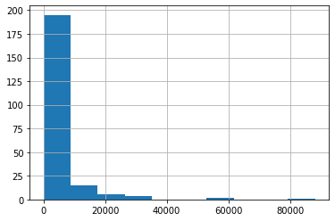

```python
%matplotlib inline
nbhd_reviews.hist()
```

This plot suggests that the vast majority of neighborhoods have only very few reviews, with just a handful of outliers (those ranked at the top in our previous computed cell) having the number of reviews upward of 40000.

## Part 2. ML Life Cycle: Business Understanding and Problem Formulation

In this part of the lab, you will practice the first step of the machine learning life cycle: business understanding and problem formulation.

Recall that the first step of the machine learning life cycle involves understanding and formulating your ML business problem, and the second step involves data understanding and preparation. In this lab however, we will first provide you with data and have you formulate a machine learning business problem based on that data.

We have provided you with four datasets that you will use to formulate a machine learning problem.

1. **HousingPrices.csv**: dataset that contains information about a house's characteristics (number of bedrooms, etc.) and its purchase price.
2. **Top100Restaurants2020.csv**: dataset that contains information about 100 top rated restaurants in 2020.
3. **ZooData.csv**: dataset that contains information about a variety of animals and their characteristics.
4. **FlightInformation.csv**: dataset that contains flight information.

The code cells below use the specified paths and names of the files to load the data into four different DataFrames.

**Task \#1**: After you run a code cell below to load the data, use some of the techniques you have practiced to inspect the data. Do the following:

1. Inspect the first 10 rows of each DataFrame.
2. Inspect all of the column names in each DataFrame.
3. Obtain the shape of each DataFrame.

(Note: You can add more cells below to accomplish this task by going to the `Insert` Menu and clicking on `Insert Cell Below`. By default, the new code cell will be of type `Code`.)

**Task \#2**: Once you have an idea of what is contained in a dataset, you will formulate a machine learning problem for that dataset. This will be a predictive problem. For example, the Airbnb dataset you worked with above can be used to train a machine learning model that can predict the price of a new Airbnb.

Come up with at least one machine learning problem per dataset. Specify what you would like to use the data to predict in the future. Since these will be supervised learning problems, specify whether it is a classification (binary or multiclass) or a regression problem. List the label and feature columns.

Note: Make sure you successfully ran the cell above that loads the `OS` module prior to running the cells below.

**Housing Prices Dataset**:

```python
filename1 = os.path.join(os.getcwd(), "data", "HousingPrices.csv")

dataFrame1 = pd.read_csv(filename1)
```

Inspect the data:

```python
dataFrame1.head(10)
```

|  | price | area | bedrooms | bathrooms | stories | mainroad | guestroom | basement | hotwaterheating | airconditioning | parking | prefarea | furnishingstatus |
| --- | --- | --- | --- | --- | --- | --- | --- | --- | --- | --- | --- | --- | --- |
| 0 | 13300000 | 7420 | 4 | 2 | 3 | yes | no | no | no | yes | 2 | yes | furnished |
| 1 | 12250000 | 8960 | 4 | 4 | 4 | yes | no | no | no | yes | 3 | no | furnished |
| 2 | 12250000 | 9960 | 3 | 2 | 2 | yes | no | yes | no | no | 2 | yes | semi-furnished |
| 3 | 12215000 | 7500 | 4 | 2 | 2 | yes | no | yes | no | yes | 3 | yes | furnished |
| 4 | 11410000 | 7420 | 4 | 1 | 2 | yes | yes | yes | no | yes | 2 | no | furnished |
| 5 | 10850000 | 7500 | 3 | 3 | 1 | yes | no | yes | no | yes | 2 | yes | semi-furnished |
| 6 | 10150000 | 8580 | 4 | 3 | 4 | yes | no | no | no | yes | 2 | yes | semi-furnished |
| 7 | 10150000 | 16200 | 5 | 3 | 2 | yes | no | no | no | no | 0 | no | unfurnished |
| 8 | 9870000 | 8100 | 4 | 1 | 2 | yes | yes | yes | no | yes | 2 | yes | furnished |
| 9 | 9800000 | 5750 | 3 | 2 | 4 | yes | yes | no | no | yes | 1 | yes | unfurnished |

Formulate ML Business Problem:

**Restaurants Dataset**:

```python
filename2 = os.path.join(os.getcwd(), "data", "Top100Restaurants2020.csv")

dataFrame2 = pd.read_csv(filename2)
```

Inspect the data:

```python
dataFrame2.head(10)
```

|  | Rank | Restaurant | Sales | Average Check | City | State | Meals Served | Category |
| --- | --- | --- | --- | --- | --- | --- | --- | --- |
| 0 | 1 | Carmine's (Times Square) | 39080335.0 | 40 | New York | N.Y. | 469803.0 | Italian/Pizza |
| 1 | 2 | The Boathouse Orlando | 35218364.0 | 43 | Orlando | Fla. | 820819.0 | Steak/ seafood |
| 2 | 3 | Old Ebbitt Grill | 29104017.0 | 33 | Washington | D.C. | 892830.0 | Fine Dining/Varied Menu |
| 3 | 4 | LAVO Italian Restaurant & Nightclub | 26916180.0 | 90 | New York | N.Y. | 198500.0 | Italian/Pizza |
| 4 | 5 | Bryant Park Grill & Cafe | 26900000.0 | 62 | New York | N.Y. | 403000.0 | Casual Dining/ Varied Menu |
| 5 | 6 | Gibsons Bar & Steakhouse | 25409952.0 | 80 | Chicago | Ill. | 348567.0 | Steak/ seafood |
| 6 | 7 | Top of the World at the STRAT | 25233543.0 | 103 | Las Vegas | Nev. | 246054.0 | Fine Dining/Varied Menu |
| 7 | 8 | Maple & Ash | 24837595.0 | 99 | Chicago | Ill. | 210832.0 | Steak/ seafood |
| 8 | 9 | Balthazar | 24547800.0 | 87 | New York | N.Y. | 519000.0 | French |
| 9 | 10 | Smith & Wollensky | 24501000.0 | 107 | New York | N.Y. | 257364.0 | Steak/ seafood |

Formulate ML Business Problem:

**Zoo Dataset**:

```python
filename3 = os.path.join(os.getcwd(), "data", "ZooData.csv")

dataFrame3 = pd.read_csv(filename3)
```

Inspect the data:

```python
dataFrame3.head(10)
```

|  | animal_name | hair | feathers | eggs | milk | airborne | aquatic | predator | toothed | backbone | breathes | venomous | fins | legs | tail | domestic | catsize | class_type |
| --- | --- | --- | --- | --- | --- | --- | --- | --- | --- | --- | --- | --- | --- | --- | --- | --- | --- | --- |
| 0 | aardvark | True | False | False | True | False | False | True | True | True | True | False | False | 4 | False | False | True | Mammal |
| 1 | antelope | True | False | False | True | False | False | False | True | True | True | False | False | 4 | True | False | True | Mammal |
| 2 | bass | False | False | True | False | False | True | True | True | True | False | False | True | 0 | True | False | False | Fish |
| 3 | bear | True | False | False | True | False | False | True | True | True | True | False | False | 4 | False | False | True | Mammal |
| 4 | boar | True | False | False | True | False | False | True | True | True | True | False | False | 4 | True | False | True | Mammal |
| 5 | buffalo | True | False | False | True | False | False | False | True | True | True | False | False | 4 | True | False | True | Mammal |
| 6 | calf | True | False | False | True | False | False | False | True | True | True | False | False | 4 | True | True | True | Mammal |
| 7 | carp | False | False | True | False | False | True | False | True | True | False | False | True | 0 | True | True | False | Fish |
| 8 | catfish | False | False | True | False | False | True | True | True | True | False | False | True | 0 | True | False | False | Fish |
| 9 | cavy | True | False | False | True | False | False | False | True | True | True | False | False | 4 | False | True | False | Mammal |

Formulate ML Business Problem:

**Flight Dataset**:

```python
filename4 = os.path.join(os.getcwd(), "data", "FlightInformation.csv")

dataFrame4 = pd.read_csv(filename4)
```

Inspect the data:

```python
dataFrame4.head(10)
```

|  | id | Airline | Flight | AirportFrom | AirportTo | DayOfWeek | Time | Length | Delay |
| --- | --- | --- | --- | --- | --- | --- | --- | --- | --- |
| 0 | 1 | CO | 269 | SFO | IAH | 3 | 15 | 205 | 1 |
| 1 | 2 | US | 1558 | PHX | CLT | 3 | 15 | 222 | 1 |
| 2 | 3 | AA | 2400 | LAX | DFW | 3 | 20 | 165 | 1 |
| 3 | 4 | AA | 2466 | SFO | DFW | 3 | 20 | 195 | 1 |
| 4 | 5 | AS | 108 | ANC | SEA | 3 | 30 | 202 | 0 |
| 5 | 6 | CO | 1094 | LAX | IAH | 3 | 30 | 181 | 1 |
| 6 | 7 | DL | 1768 | LAX | MSP | 3 | 30 | 220 | 0 |
| 7 | 8 | DL | 2722 | PHX | DTW | 3 | 30 | 228 | 0 |
| 8 | 9 | DL | 2606 | SFO | MSP | 3 | 35 | 216 | 1 |
| 9 | 10 | AA | 2538 | LAS | ORD | 3 | 40 | 200 | 1 |

Formulate ML Business Problem:

**Next Steps**: The second step of the machine learning life cycle is data understanding and data preparation. You practiced some aspects of data understanding when using NumPy and Pandas to inspect the Airbnb dataset. You will learn more about this second step of the machine learning life cycle in the next unit.